# NCSS Lab Data via Soil Data Access

D.E. Beaudette and Jason Nemecek

2025-12-19

# 1 Introduction

This document demonstrates querying Soil Data Access (SDA) for NCSS laboratory characterization data. A simplified, searchable interface to the associated metadata is included to assist with field names, units of measure, table names, and table linkages.

# 2 Setup

The following R packages are used in this document.

```r
install.packages('soilDB')
install.packages('aqp')
install.packages('mapview')
install.packages('sf')
install.packages('soiltexture')
install.packages('scales')
install.packages('Hmisc')
```

# 3 Table Relationships

Open in a new browser tab for a larger version. [Interactive version](https://jneme910.github.io/Lab_Data_Mart_Documentation/Documents/SDA_KSSL_Data_model.html).

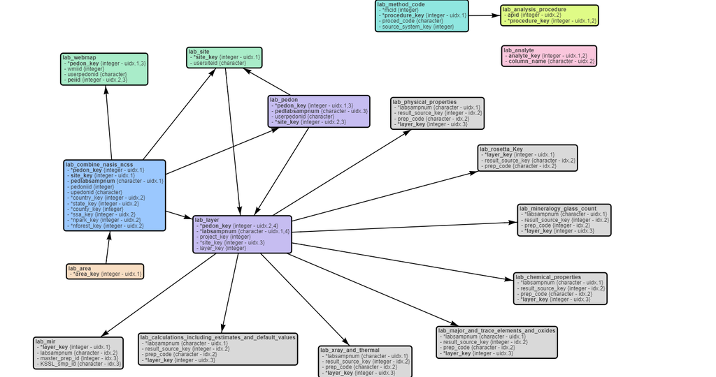

## 3.1 Table Descriptions

| Table | Description |
| --- | --- |
| lab_analysis_procedure | The Analysis Procedure table is a lookup table which contains information about the analysiscprocedure. The analysis procedure is the basic analytical method applied to a prepared sample. This procedu… |
| lab_analyte | The Analyte table is a lookup table which contains information about an analyte (primary result of an analysis by a procedure). The LIMS uses this data to format the data, provide abbreviations and un… |
| lab_area | A lookup table containing the list of valid NRCS areas, both current and obsolete for Country, County, Soil Survey Area and MLRA. Note that a soil survey area code is a concatenation of a U.S. state F… |
| lab_calculations_including_estimates_and_default_values | This table contains the results of calculations using measured, estimated and default values. |
| lab_chemical_properties | This table contains the results of the analysis of chemical properties of the soil that are measured by the KSSL and cooperating university laboratories. |
| lab_combine_nasis_ncss | This table is a linkage betwwen NASIS Pedon morphological and the Lab data. This table stores information about locations, layers or horizons of a pedon that has had samples submitted to the SSL at th… |
| lab_layer | The Layer table contains information about the layer, including the field identifier, horizon designation, reporting, and depths. Layer in the LIMS can be a true soil horizon or a reporting layer whic… |
| lab_major_and_trace_elements_and_oxides | This table contains major and trace elements, total oxides, x-ray data and the method codes related to the methods used. |
| lab_method_code | This table relates a non-connotative method code with the preparation, instrument, size fraction, analyte, procedure (if any) and calculation algorithm (if any) represented by that method code. |
| lab_mineralogy_glass_count | The Optical Mineralogy glass count Count Data table holds the raw data for the sample. The table hold what type of optical count, the size fraction and replicate number. |
| lab_mir | Spectroscopy is the study of the interaction between matter and electromagnetic radiation. It is based on the principle that molecular vibrations and electronic transitions associated with soil consti… |
| lab_mir_wavelength | The lab_mir_wavelength table is a lookup of the collection of wavelengths used for sampling the samples |
| lab_pedon | The LIMS Pedon table holds general information about the pedon. The pedon is associated with a site. The converse is not necessarily true. |
| lab_physical_properties | This table contains the results of analysis of physical properties of the soil that are measured by the KSSL and cooperating university laboratories. |
| lab_preparation | The Preparation table holds the information about the type of preparation, size of the orginal and final fractions prepared, default container type and preparation sort order. |
| lab_rosetta_key | ROSETTA, which implements five hierarchical pedotransfer functions (PTFs) for the estimation of water retention, and the saturated and unsaturated hydraulic conductivity. |
| lab_site | The LIMS Site table holds the site (location) information about the place where the samples or pedon originated. |
| lab_webmap | This table is used to develop a webmap which is used to interactive display of geographic information pertaining to laboratory information. The interactive map offers a national database of soil chara… |
| lab_xray_and_thermal | The X-ray Diffraction Data table holds the raw data for the each mineral in the sample. |
| table_name | table_description |

## 3.2 Column Descriptions

|  | table_name | field_sequence | column_name | column_description |
| --- | --- | --- | --- | --- |
| 1 | lab_analysis_procedure | 1 | apid | An internal ID (integer) that is part (or all) of a key that uniquely identifies a record. Also known as part (or all) of the "primary key". This value is managed by NASIS and cannot be edited |
| 2 | lab_analysis_procedure | 9 | Links_to_SSIR_42_V_5 | Links_to_SSIR_42_V_5 |
| 3 | lab_analysis_procedure | 10 | notes | Notes describing decisions, issues, or other history related to the record. |
| 4 | lab_analysis_procedure | 8 | PDF_pg | PDF_pg |
| 5 | lab_analysis_procedure | 5 | proced_abbrev | A character string containing the procedure abbreviation. |
| 6 | lab_analysis_procedure | 6 | proced_desc | proced_desc |
| 7 | lab_analysis_procedure | 4 | proced_name | A character string containing the Soil Survey Laboratory name of the procedure. |
| 8 | lab_analysis_procedure | 2 | procedure_key | procedure key |
| 9 | lab_analysis_procedure | 3 | requested_anal_name | requested_anal_name |
| 10 | lab_analysis_procedure | 7 | SSIR_5_Page | SSIR_5_Page |

[output cut: 994 more lines]

# 4 Manually Written Queries

Load required libraries.

```r
library(soilDB)
library(aqp)
```

## 4.1 Using Area “Overlap” Information

```r
# get a listing of the available area types
SDA_query("SELECT DISTINCT area_type FROM lab_area;")

# get a listing of the MLRA codes
x <- SDA_query("SELECT DISTINCT area_code FROM lab_area WHERE area_type = 'mlra' ;")
```

## 4.2 Query Lab Pedons by MLRA

Query record IDs and WGS84 coordinates for MLRA ‘130B’. Note the use of “mlra_key” from the lab_combine_nasis_ncss table for specification of the JOIN constraint.

```r
sql <- "
SELECT
pedon_key, pedlabsampnum, pedoniid, upedonid, longitude_decimal_degrees, latitude_decimal_degrees,
area_code
FROM
lab_combine_nasis_ncss
JOIN
lab_area ON area_key = mlra_key AND area_type = 'mlra'
WHERE area_code = '130B'
;"

pedons <- SDA_query(sql)
nrow(pedons)
```

```
## [1] 95
```

```r
head(pedons)
```

```
##   pedon_key pedlabsampnum pedoniid      upedonid longitude_decimal_degrees latitude_decimal_degrees
## 1     12313       85P0630  1295947    85NC075001                 -83.71833                 35.35722
## 2     12314       85P0631  1333521    85NC075002                 -83.71933                 35.35902
## 3     12316       85P0633  1295949 S1985NC099002                 -83.19361                 35.51417
## 4     12317       85P0634   323579  1991NC099400                 -83.13515                 35.35122
## 5     13419       86P0747   123590    86NC039004                 -83.95935                 35.19736
## 6     13422       86P0750  1305994 1986NC087005C                 -82.96315                 35.45174
##   area_code
## 1      130B
## 2      130B
## 3      130B
## 4      130B
## 5      130B
## 6      130B
```

## 4.3 Sequoia-Kings Canyon (CA792)

This example demonstrates a 2-stage approach to identifying pedons that have been sampled for laboratory characterization by soil survey area symbol.

Querying by soil survey area code is useful for reviewing those data collected to support a new soil survey or to perform updates to an existing soil survey.

```r
sql <- "
SELECT
pedon_key, pedlabsampnum, pedoniid, upedonid, longitude_decimal_degrees, latitude_decimal_degrees,
area_code
FROM
lab_combine_nasis_ncss
JOIN
lab_area ON area_key = ssa_key AND area_type = 'ssa'
WHERE area_code = 'CA792'
;"

pedons <- SDA_query(sql)
nrow(pedons)
```

```
## [1] 39
```

```r
head(pedons)
```

```
##   pedon_key pedlabsampnum pedoniid      upedonid longitude_decimal_degrees latitude_decimal_degrees
## 1     69913      13N97435  1147616 S2013CA107001                 -118.7045                 36.44555
## 2     69914      13N97436  1147617 S2013CA107002                 -118.9434                 36.72390
## 3     69915      13N97437  1147615 S2013CA019003                 -118.6617                 36.79047
## 4     70018       13N0500  1147611 S2012CA019001                 -118.5989                 37.10028
## 5     70019       13N0501  1147612 S2012CA019002                 -118.6431                 37.12112
## 6     70020       13N0502  1147613 S2012CA019003                 -118.6934                 37.15224
##   area_code
## 1     CA792
## 2     CA792
## 3     CA792
## 4     CA792
## 5     CA792
## 6     CA792
```

Review pedon locations with an interactive map.

```r
library(mapview)
library(sf)

pedons.sub <- subset(pedons, subset = !is.na(longitude_decimal_degrees) & !is.na(latitude_decimal_degrees))

pedons.sf <- st_as_sf(pedons.sub, coords = c('longitude_decimal_degrees', 'latitude_decimal_degrees'), crs = 4326)
mapview(pedons.sf)
```

[interactive chart not shown]

Connect physical and chemical properties to sampled “layers” (usually genetic soil horizons).

Join conditions: * lab_pedon -> lab_layer [pedon_key] * lab_layer -> lab_physical_properties [labsampnum]

```r
# make a quoted vector of pedon keys, for use in the next query
pedon.keys <- format_SQL_in_statement(pedons$pedon_key)

## layer + physical properties
sql <- sprintf("
SELECT
l.pedon_key, l.labsampnum, hzn_top, hzn_bot, hzn_desgn,
sand_total, silt_total, clay_total, particle_size_method,
ph_h2o, ph_h2o_method,
bulk_density_third_bar, bulk_density_third_bar_method
FROM
lab_layer AS l
JOIN lab_physical_properties AS p ON l.labsampnum = p.labsampnum
JOIN lab_chemical_properties AS c ON l.labsampnum = c.labsampnum
WHERE l.pedon_key IN %s
ORDER BY l.pedon_key, hzn_top
;", pedon.keys)

hz <- SDA_query(sql)
nrow(hz)
```

```
## [1] 222
```

```r
head(hz)
```

```
##   pedon_key labsampnum hzn_top hzn_bot hzn_desgn sand_total silt_total clay_total
## 1     69913   13N13137       0       2        Oi         NA         NA         NA
## 2     69913   13N13138       2       7         A       71.2       21.7        7.1
## 3     69913   13N13139       7      19       Bt1       75.0       19.1        5.9
## 4     69913   13N13140      19      39       Bt2       79.9       15.7        4.4
## 5     69913   13N13141      39      64       Bt3       83.0       11.9        5.1
## 6     69913   13N13142      64      92       Bt4       83.3       10.6        6.1
##   particle_size_method ph_h2o ph_h2o_method bulk_density_third_bar bulk_density_third_bar_method
## 1                 <NA>     NA          <NA>                     NA                          <NA>
## 2               3A1a1a    6.1        4C1a2a                   1.12                         DbWR1
## 3               3A1a1a    5.3        4C1a2a                   1.31                         DbWR1
## 4               3A1a1a    5.3        4C1a2a                   1.49                         DbWR1
## 5               3A1a1a    5.5        4C1a2a                   1.62                         DbWR1
## 6               3A1a1a    5.6        4C1a2a                   1.79                         DbWR1
```

```r
# unique set of methods
table(hz$particle_size_method)
```

```
##
## 3A1a1a
##    201
```

Investigate soil texture.

```r
# remove missing values
ssc <- na.omit(hz[, c('sand_total', 'silt_total', 'clay_total')])

# re-name columns, required by textureTriangleSummary()
names(ssc) <- c('SAND', 'SILT', 'CLAY')

textureTriangleSummary(ssc, cex = 0.5)
```

[figure not shown]

Review thematic (1:1 soil:water pH) soil profile sketches.

```r
# make a copy and
x <- hz

# init SoilProfileCollection
depths(x) <- pedon_key ~ hzn_top + hzn_bot
hzdesgnname(x) <- 'hzn_desgn'

par(mar = c(0, 0, 3, 0))
plotSPC(
  x,
  print.id = FALSE,
  name.style = 'center-center',
  width = 0.33,
  color = 'ph_h2o',
  depth.axis = list(cex = 0.85, line = -4)
)
```

[figure not shown]

## 4.4 Investigate Bx Horizons

```r
library(soiltexture)
library(scales)

# SDA Interface, this requires a network connection but otherwise it just WORKS!
qq <- "SELECT
hzn_top, hzn_bot, hzn_desgn, sand_total AS sand, silt_total AS silt, clay_total AS clay
FROM lab_layer
JOIN lab_physical_properties ON lab_layer.labsampnum = lab_physical_properties.labsampnum
WHERE hzn_desgn LIKE 'B%x%' ;"

# run query
bx <- SDA_query(qq)

##
## summarize sand, silt, clay for Bx horizons
##

# number of records
nrow(bx)
```

```
## [1] 4076
```

```r
# preview data
head(bx)
```

```
##   hzn_top hzn_bot hzn_desgn sand silt clay
## 1      94     120       Bx1  4.2 77.6 18.2
## 2     120     135       Bx2  2.9 77.9 19.2
## 3     135     150       Bx3  1.9 70.9 27.2
## 4      56      99       Bx1 58.4 27.9 13.7
## 5      99     125       Bx2 51.6 34.5 13.9
## 6     125     165       Bx3 47.9 39.1 13.0
```

```r
# extract components of texture, removing rows with missing data
ssc <- bx[, c('sand', 'silt', 'clay')]
ssc <- na.omit(ssc)

# adjust names for plotting with TT.plot()
# names must be SAND, SILT, CLAY
names(ssc) <- toupper(names(ssc))

# test of bogus data
ssc$sum <- rowSums(ssc[, c('SAND', 'SILT', 'CLAY')])
# > 5% deviation from 100%
idx <- which(abs(ssc$sum - 100) > 5)

# check errors: just one
ssc[idx, ]
```

```
##      SAND SILT CLAY  sum
## 3676 57.5 23.8  5.6 86.9
```

```r
# plot data
# note that there are many arguments used to adjust style
TT.plot(
  class.sys= "USDA-NCSS.TT",    # use "our" texture triangle
  tri.data=ssc,                 # data.frame with sand, silt, clay values
  main= "Bx Horizons",          # title
  tri.sum.tst=FALSE,            # do not test for exact sum(sand, silt, clay) == 100
  cex.lab=0.75,                 # scaling of label text
  cex.axis=0.75,                # scaling of axis
  cex=0.5,                      # scaling of point symbols
  col=alpha('royalblue', 0.125),  # color of point symbols, with transparency
  frame.bg.col='white',         # background color
  class.lab.col='black',        # color for texture class labels
  lwd.axis=1.5,                    # line thickness for axis
  arrows.show=TRUE
)
```

[figure not shown]

# 5 Convenience Functions

## 5.1 fetchLDM() via SDA

Safely iterate over soil series names, querying “correlated as” when present, otherwise “sampled as” when NULL.

```r
# useful for iteration with progress bar
library(purrr)

getData <- function(i) {

  # formulate WHERE clause for series 'i'
  .where <- sprintf("CASE WHEN corr_name IS NOT NULL THEN LOWER(corr_name) ELSE LOWER(samp_name) END = '%s' ", i)

  # query SDA
  lab <- fetchLDM(
    WHERE = .where,
  )

  # return results
  return(lab)
}

# series names to iterate over
taxa <- c('pierre', 'lucy', 'zook')

# result is a list of SoilProfileCollection objects
s <- map(taxa, .f = getData, .progress = TRUE)

# flatten into a single SoilProfileCollection
s <- combine(s)

# graphicaly check a couple
par(mar = c(1, 1, 3, 3))
plotSPC(s[1:10, ], color = 'clay_total', width = 0.33, name.style = 'center-center', max.depth = 150)
```

[figure not shown]

This document is based on `aqp` version 2.3 and `soilDB` version 2.8.13.